# Diamonds quality

## 2. Find an explanation and solve the apparent paradox

The most important factor for the price of a diamond is its weight (carat). The scatterplot shows a strong (non linear) correlation between carat and price:

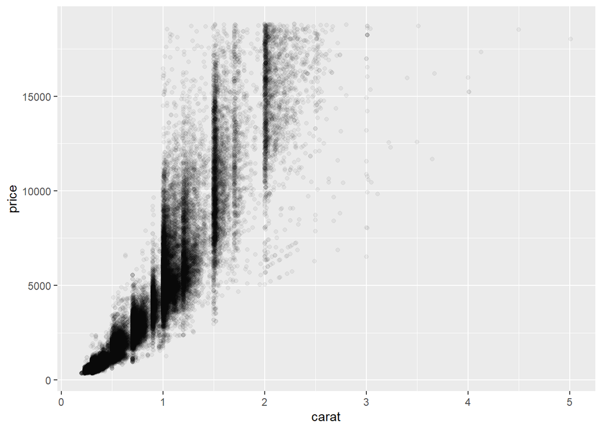

```r
ggplot(data = diamonds) +
  geom_point(mapping = aes(x = carat, y = price), alpha = 0.05)
```

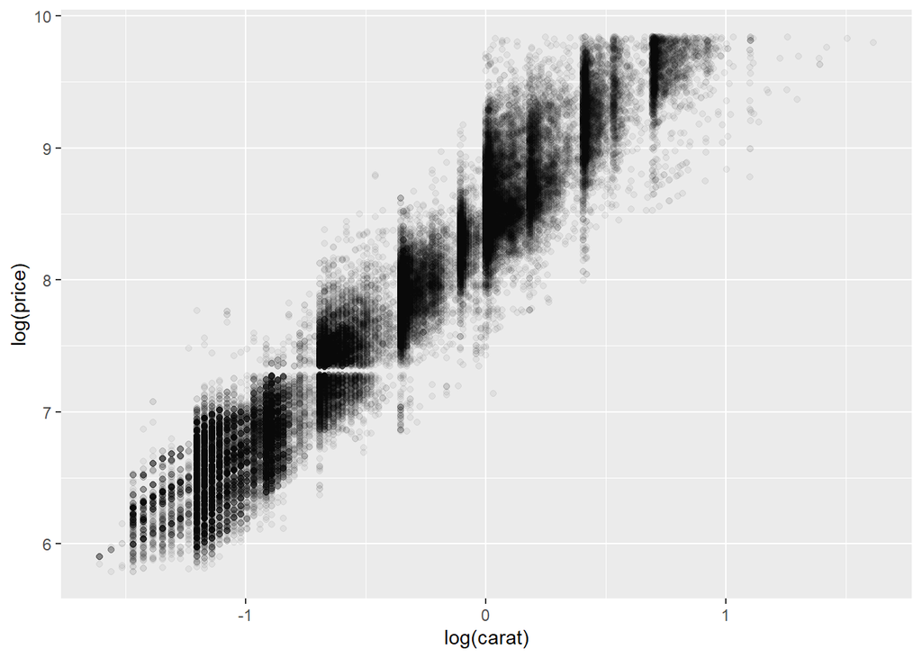

```r
# on log scales the relationship is linear
ggplot(data = diamonds) +
  geom_point(mapping = aes(x = log(carat), y = log(price)), alpha = 0.05)
```

Moreover, lower quality diamonds tend to be larger:

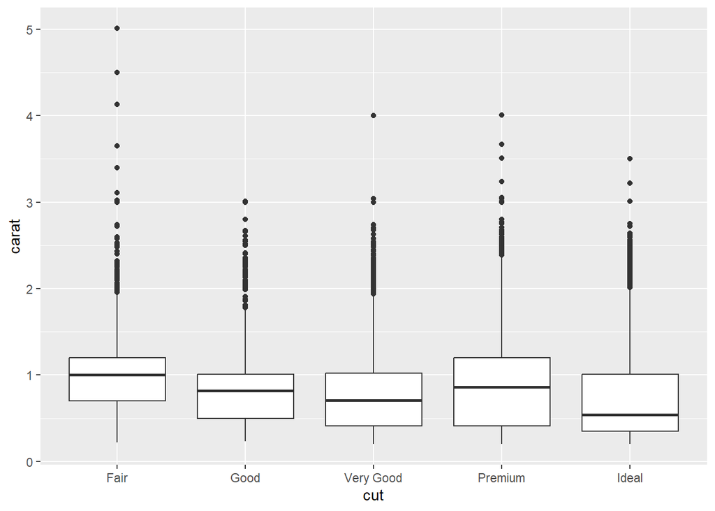

```r
ggplot(data = diamonds) +
  geom_boxplot(mapping = aes(x = cut, y = carat))
```

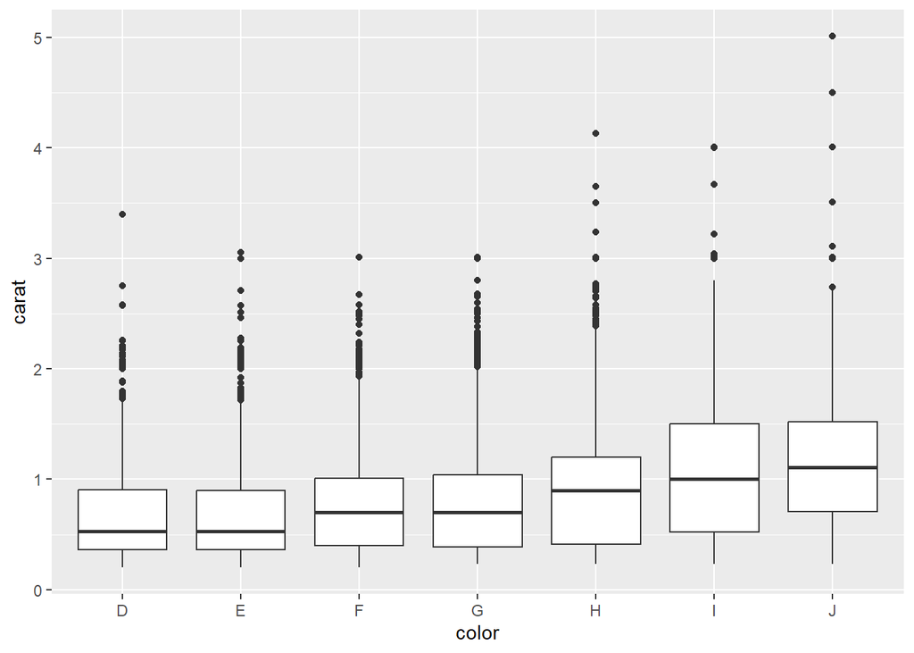

```r
ggplot(data = diamonds) +
  geom_boxplot(mapping = aes(x = color, y = carat))
```

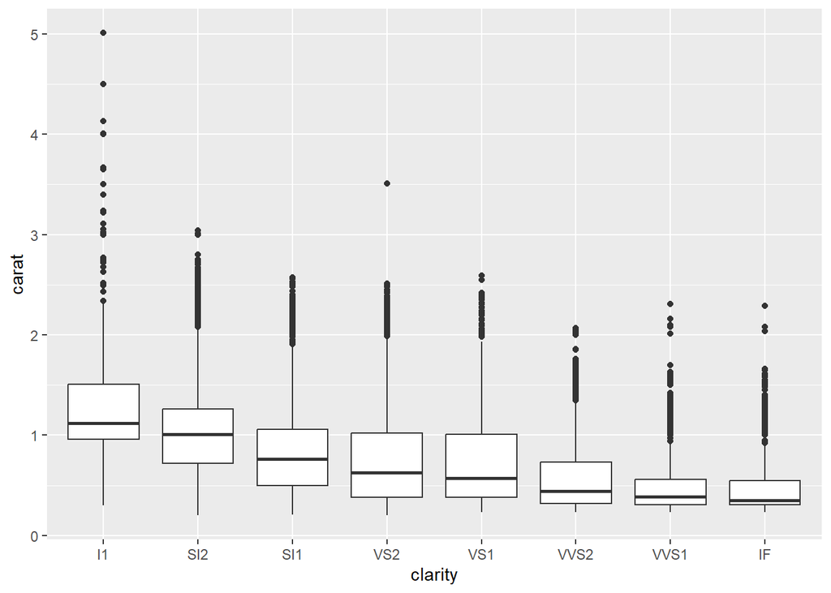

```r
ggplot(data = diamonds) +
  geom_boxplot(mapping = aes(x = clarity, y = carat))
```

Hence weight is a confounding variable: large diamonds are expensive and large diamonds often have a low quality, so low quality diamonds appear to be expensive.

To solve the paradox we remove the effect of weight with a model. We fit a linear model of log price in terms of log carat, that captures the strong pattern, and we study the residuals, that tell us what the model has missed, namely the effect of the other variables.

```r
# linear model on log scales
mod = lm(log(price) ~ log(carat), data = diamonds)
mod$coefficients
```

```
## (Intercept)  log(carat)
##    8.448661    1.675817
```

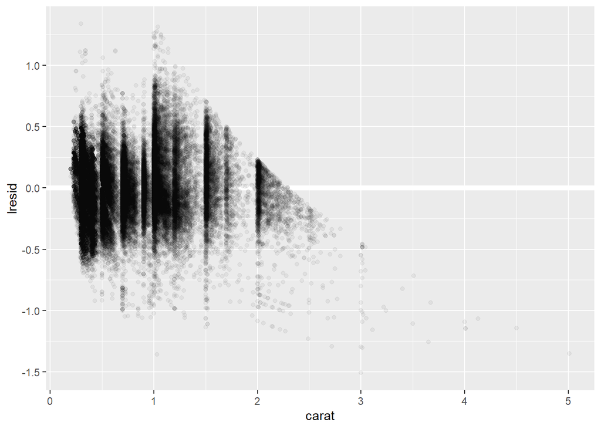

```r
# add the residuals to the data
diamonds2 =
  diamonds |>
  add_residuals(mod, "lresid")

# the residuals of the model
ggplot(diamonds2, aes(carat, lresid)) +
  geom_ref_line(h = 0) +
  geom_point(alpha = 0.05)
```

The residual of a diamond is the (log) price not explained by its weight: a positive residual means that the diamond is more expensive than expected for its weight. Now we repeat the boxplots using the residuals instead of the price:

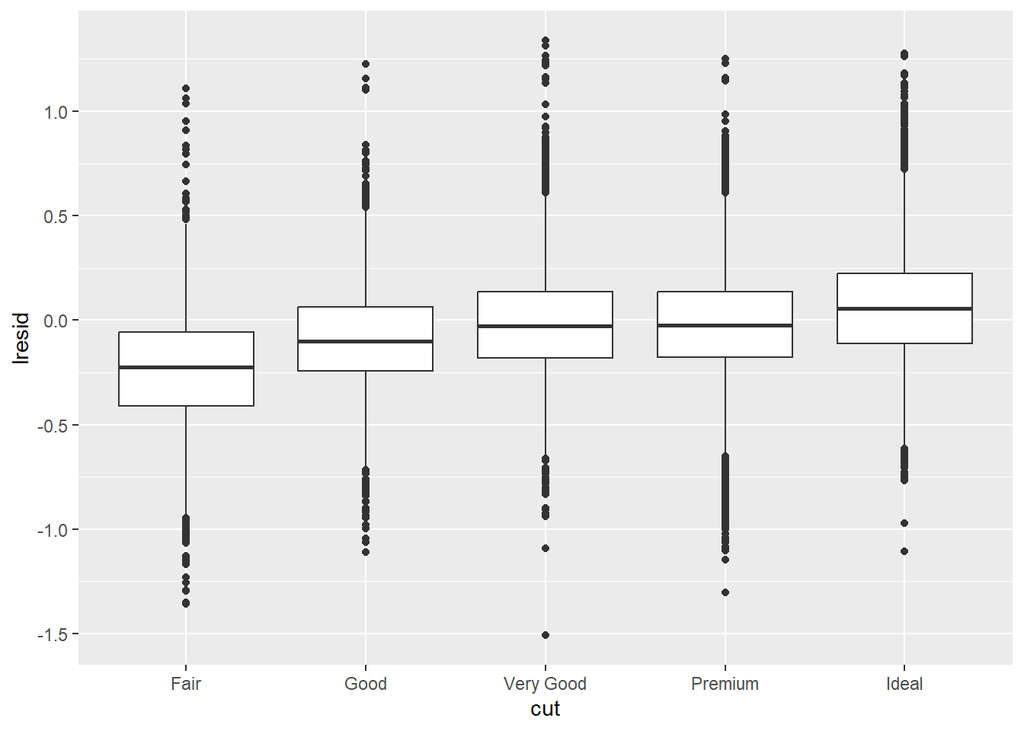

```r
ggplot(data = diamonds2) +
  geom_boxplot(mapping = aes(x = cut, y = lresid))
```

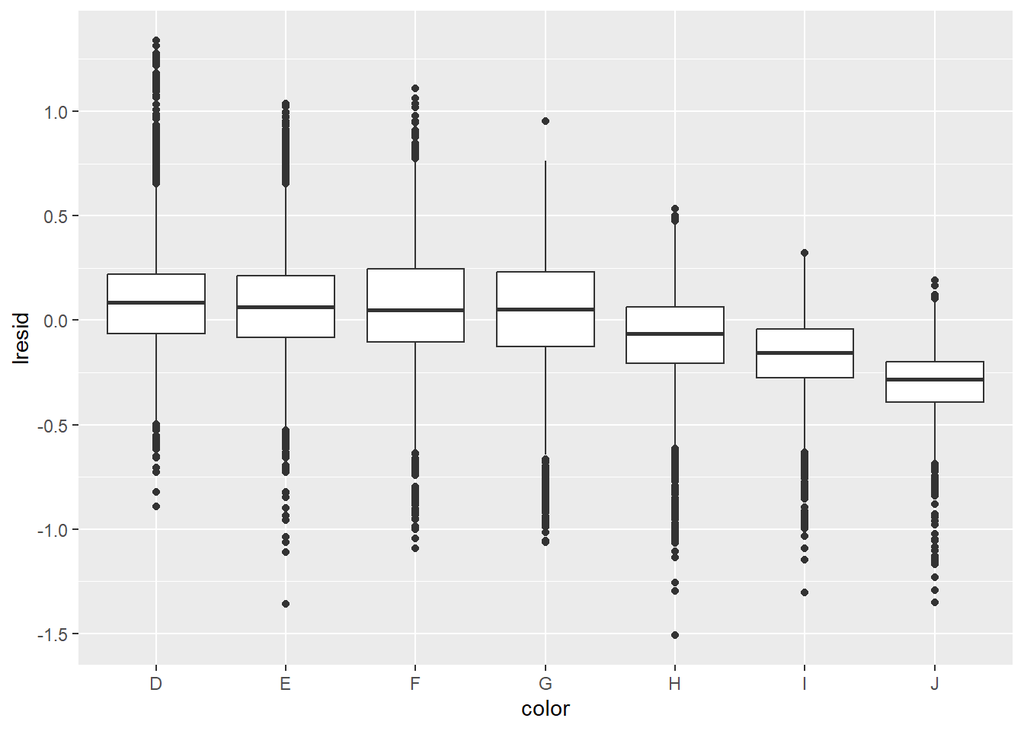

```r
ggplot(data = diamonds2) +
  geom_boxplot(mapping = aes(x = color, y = lresid))
```

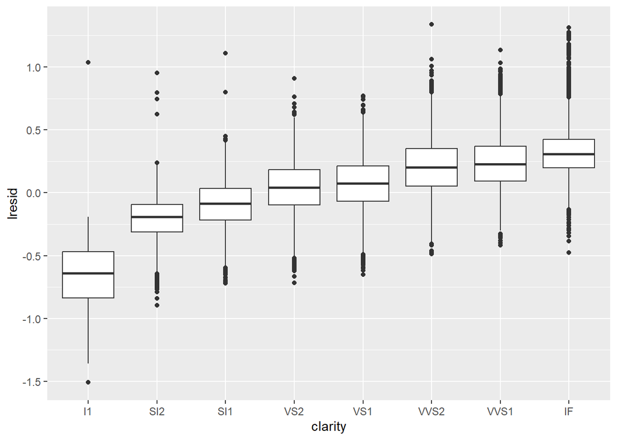

```r
ggplot(data = diamonds2) +
  geom_boxplot(mapping = aes(x = clarity, y = lresid))
```

```r
diamonds2 |>
  group_by(cut) |>
  summarise(median_resid = median(lresid))
```

```
## # A tibble: 5 × 2
##   cut       median_resid
##   <ord>            <dbl>
## 1 Fair           -0.225
## 2 Good           -0.0997
## 3 Very Good      -0.0281
## 4 Premium        -0.0227
## 5 Ideal           0.0549
```

```r
diamonds2 |>
  group_by(color) |>
  summarise(median_resid = median(lresid))
```

```
## # A tibble: 7 × 2
##   color median_resid
##   <ord>        <dbl>
## 1 D           0.0870
## 2 E           0.0622
## 3 F           0.0485
## 4 G           0.0518
## 5 H          -0.0653
## 6 I          -0.157
## 7 J          -0.282
```

```r
diamonds2 |>
  group_by(clarity) |>
  summarise(median_resid = median(lresid))
```

```
## # A tibble: 8 × 2
##   clarity median_resid
##   <ord>          <dbl>
## 1 I1           -0.640
## 2 SI2          -0.191
## 3 SI1          -0.0848
## 4 VS2           0.0430
## 5 VS1           0.0748
## 6 VVS2          0.201
## 7 VVS1          0.225
## 8 IF            0.307
```

Once the effect of weight is removed, the relationship is the one we expect: for diamonds of the same weight, the better the cut, the color and the clarity, the higher the price.